# Load Packages

```python
import numpy as np
import pandas as pd
from plotnine import *

from sklearn.preprocessing import StandardScaler
from sklearn.linear_model import LinearRegression, Ridge, Lasso
from sklearn.preprocessing import StandardScaler #Z-score variables
from sklearn.metrics import r2_score, mean_squared_error, mean_absolute_error
from sklearn.model_selection import train_test_split, GridSearchCV, KFold # simple TT split cv

from sklearn.pipeline import make_pipeline
from sklearn.compose import make_column_transformer
from sklearn.linear_model import SGDClassifier, SGDRegressor

from sklearn.cluster import KMeans
from sklearn.metrics import silhouette_score
from sklearn.cluster import DBSCAN

import scipy as sp
```

We had to restructure many of our questions and the planned analysis to answer these questions.

**Original questions:**

**Nic:**

**1)** How significant are variables like intentional walks, sacrifice bunts, sacrifice flies, double plays, and caught stealing going to be in predicting a player’s salary? Will they get removed by a regularization model? **2)** How accurate are your models in predicting players’ salaries based on mean squared error? **3)** How accurate are your clustering models in grouping players by their skills or salary levels based on silhouette scores?

**Obada:**

**4)** Which variables contribute the most to deciding how long a player's contract will be? **5)** Do Batters with higher salaries actually play that much better than Batters with lower salaries? How does a change in salary affect a player's performance? **6)** Which 3 stats for a batter are the most effective at determining their salary?

**New questions:**

**Nic:**

**1)** How accurate is our model at predicting salaries? **2)** What are the top 5 most significant variables in determining salaries? **3)** How strongly related is each variable to salary? Are there any variables with strong relationships to each other?

**Obada:**

**4)** Do batters with higher salaries actually play that much better than batters with lower salaries? **5)** Are there any players who are overpaid? How about underpaid? How can we tell? **6)** How well does our model do with predicting the salary for unseen data?

Originally our plan was to make a lasso model to determine variables and then make another linear model off of the chosen variables, but we eventually realized that lasso produces a linear model so we instead created a linear model based off variables we thought were the best and based off of their correlation to salary. We also had to scratch questions 1,4,6 because they were very similar so we created the new question 3,5,6. Question 3 is where we chose our own variables to make a linear mode. In question 5 we analyzed results from question 1 to see if individual players were under/over paid and if we thought this was correct. In question 6 we applied our lasso model to a few players of our choice. We also used a Gaussian Mixtures model for question 4 instead of the K-Means model that we wanted to use originally.

# Load Dataset

Data found on Kaggle.com Lists all players' salaries in 2014 as well as basic statistics

```python
pd.set_option("display.max_rows", 15, "display.max_columns", 15)
salaries = pd.read_csv('/Users/nicvamis/Desktop/CPSC392/Salary Data')

print(salaries.columns)
salaries
```

```
Index(['Unnamed: 0', 'league_id', 'player_id', 'stint', 'team_id', 'year', 'g',
       'ab', 'r', 'h', 'double', 'triple', 'hr', 'rbi', 'sb', 'cs', 'bb', 'so',
       'ibb', 'hbp', 'sh', 'sf', 'g_idp', 'salary', 'pos', 'name'],
      dtype='object')
```

|  | Unnamed: 0 | league_id | player_id | stint | team_id | year | g | ... | hbp | sh | sf | g_idp | salary | pos | name |
| --- | --- | --- | --- | --- | --- | --- | --- | --- | --- | --- | --- | --- | --- | --- | --- |
| 0 | 0 | trade | fuldsa01 | 3.0 | trade | 2014 | 113 | ... | 0.0 | 6.0 | 2.0 | 2.0 | 1750000 | OF | Sam Fuld |
| 1 | 1 | trade | johnske05 | 3.0 | trade | 2014 | 106 | ... | 2.0 | 0.0 | 1.0 | 3.0 | 1500000 | 3B | Kelly Johnson |
| 2 | 2 | trade | marisja01 | 2.0 | trade | 2014 | 65 | ... | 3.0 | 2.0 | 3.0 | 2.0 | 511200 | OF | Jake Marisnick |
| 3 | 3 | trade | jacksau01 | 2.0 | trade | 2014 | 154 | ... | 2.0 | 1.0 | 9.0 | 15.0 | 7700000 | OF | Austin Jackson |
| 4 | 4 | trade | youngch04 | 2.0 | trade | 2014 | 111 | ... | 5.0 | 1.0 | 3.0 | 3.0 | 2500000 | OF | Chris Young |
| ... | ... | ... | ... | ... | ... | ... | ... | ... | ... | ... | ... | ... | ... | ... | ... |
| 404 | 404 | AL | ackledu01 | 1.0 | SEA | 2014 | 143 | ... | 3.0 | 3.0 | 2.0 | 10.0 | 2600000 | OF | Dustin Ackley |
| 405 | 405 | AL | millebr02 | 1.0 | SEA | 2014 | 123 | ... | 2.0 | 3.0 | 3.0 | 2.0 | 527600 | SS | Brad Miller |
| 406 | 406 | NL | pederjo01 | 1.0 | LAN | 2014 | 18 | ... | 0.0 | 1.0 | 0.0 | 1.0 | 510000 | OF | Joc Pederson |
| 407 | 407 | AL | gonzama01 | 1.0 | HOU | 2014 | 103 | ... | 4.0 | 4.0 | 0.0 | 6.0 | 1062500 | SS | Marwin Gonzalez |
| 408 | 408 | NL | grandya01 | 1.0 | SDN | 2014 | 128 | ... | 2.0 | 0.0 | 6.0 | 7.0 | 693000 | C | Yasmani Grandal |

409 rows × 26 columns

# Cleaning Data

Calculating basic statistics such as batting average, slugging %, on base %

```python
salaries["avg"] = salaries["h"] / salaries["ab"]

single = salaries["h"] - (salaries["hr"] + salaries["double"] + salaries["triple"])

salaries["slg"] = (single + (salaries["double"]*2) + (salaries["triple"]*3) + salaries["hr"]*4 ) / salaries["ab"]

salaries["pa"] = salaries["ab"] + salaries["bb"] + salaries["ibb"] + salaries["hbp"] + salaries["sh"] + salaries["sf"]

salaries["obp"] = (salaries["h"] + salaries["bb"] + salaries["hbp"])/(salaries["pa"])

salaries["ops"] = salaries["obp"] + salaries["slg"]

salaries["hr_per_ab"] = (salaries["hr"])/(salaries["ab"])

salaries["k_percentage"] = (salaries["so"])/(salaries["pa"])
salaries["bb_percentage"] = (salaries["bb"])/(salaries["pa"])

salaries["salaryM"] = salaries["salary"]/1000000

dummies = pd.get_dummies(salaries["pos"])

salaries = pd.concat([salaries,dummies], axis = 1)
```

[output not shown]

```python
salaries_clean = salaries[['name', 'player_id', 'pos', 'year', 'g', 'stint', 'team_id',
       '1B', '2B', '3B', 'C', 'OF', 'SS',
       'ab', 'pa', 'avg','slg', 'obp', 'ops', 'r', 'h', 'double', 'triple', 'hr', 'rbi', 'sb', 'cs', 'bb', 'so',
       'ibb', 'hbp', 'sh', 'sf', 'g_idp', 'hr_per_ab', 'k_percentage', 'bb_percentage', 'salaryM', 'salary']]
salaries_clean.columns
```

```
Index(['name', 'player_id', 'pos', 'year', 'g', 'stint', 'team_id', '1B', '2B',
       '3B', 'C', 'OF', 'SS', 'ab', 'pa', 'avg', 'slg', 'obp', 'ops', 'r', 'h',
       'double', 'triple', 'hr', 'rbi', 'sb', 'cs', 'bb', 'so', 'ibb', 'hbp',
       'sh', 'sf', 'g_idp', 'hr_per_ab', 'k_percentage', 'bb_percentage',
       'salaryM', 'salary'],
      dtype='object')
```

```python
salaries_clean
```

|  | name | player_id | pos | year | g | ... | hr_per_ab | k_percentage | bb_percentage | salaryM | salary |
| --- | --- | --- | --- | --- | --- | --- | --- | --- | --- | --- | --- |
| 0 | Sam Fuld | fuldsa01 | OF | 2014 | 113 | ... | 0.011396 | 0.155941 | 0.106436 | 1.750000 | 1750000 |
| 1 | Kelly Johnson | johnske05 | 3B | 2014 | 106 | ... | 0.026415 | 0.239057 | 0.097643 | 1.500000 | 1500000 |
| 2 | Jake Marisnick | marisja01 | OF | 2014 | 65 | ... | 0.013575 | 0.279167 | 0.033333 | 0.511200 | 511200 |
| 3 | Austin Jackson | jacksau01 | OF | 2014 | 154 | ... | 0.006700 | 0.219512 | 0.071646 | 7.700000 | 7700000 |
| 4 | Chris Young | youngch04 | OF | 2014 | 111 | ... | 0.033846 | 0.190217 | 0.086957 | 2.500000 | 2500000 |
| 5 | Jordan Pacheco | pachejo01 | C | 2014 | 69 | ... | 0.000000 | 0.163636 | 0.054545 | 0.900000 | 900000 |
| 6 | Geovany Soto | sotoge01 | C | 2014 | 24 | ... | 0.012500 | 0.218391 | 0.068966 | 1.500000 | 1500000 |
| 7 | Yangervis Solarte | solarya01 | 3B | 2014 | 131 | ... | 0.021322 | 0.108209 | 0.098881 | 0.516400 | 516400 |
| 8 | Gerardo Parra | parrage01 | OF | 2014 | 150 | ... | 0.017013 | 0.172712 | 0.055268 | 6.237500 | 6237500 |
| 9 | Emilio Bonifacio | bonifem01 | OF | 2014 | 110 | ... | 0.007614 | 0.198598 | 0.060748 | 3.000000 | 3000000 |
| 10 | Chase Headley | headlch01 | 3B | 2014 | 135 | ... | 0.027660 | 0.229323 | 0.095865 | 13.000000 | 13000000 |
| 11 | Zach Walters | walteza01 | OF | 2014 | 62 | ... | 0.078740 | 0.350365 | 0.065693 | 0.509600 | 509600 |
| 12 | Kendrys Morales | moralke01 | 1B | 2014 | 98 | ... | 0.021798 | 0.168317 | 0.066832 | 6.500000 | 6500000 |
| 13 | Alejandro De Aza | deazaal01 | OF | 2014 | 142 | ... | 0.016771 | 0.224528 | 0.073585 | 5.000000 | 5000000 |
| 14 | John Mayberry | maybejo02 | OF | 2014 | 78 | ... | 0.047945 | 0.208333 | 0.119048 | 1.450000 | 1450000 |
| 15 | Nick Franklin | frankni01 | 2B | 2014 | 28 | ... | 0.012346 | 0.355556 | 0.066667 | 1.021800 | 1021800 |
| 16 | Grady Sizemore | sizemgr01 | OF | 2014 | 112 | ... | 0.014409 | 0.199475 | 0.086614 | 2.000000 | 2000000 |
| 17 | Martin Prado | pradoma01 | 3B | 2014 | 143 | ... | 0.022388 | 0.139616 | 0.045375 | 11.000000 | 11000000 |
| 18 | Nick Hundley | hundlni01 | C | 2014 | 83 | ... | 0.027523 | 0.270386 | 0.042918 | 3.100000 | 3100000 |
| 19 | Chris Denorfia | denorch01 | OF | 2014 | 121 | ... | 0.009091 | 0.195531 | 0.069832 | 2.600000 | 2600000 |
| 20 | Darwin Barney | barneda01 | 2B | 2014 | 94 | ... | 0.012658 | 0.128788 | 0.064394 | 2.525000 | 2525000 |
| 21 | J. B. Shuck | shuckja01 | OF | 2014 | 38 | ... | 0.018182 | 0.104348 | 0.026087 | 0.516000 | 516000 |
| 22 | Danny Valencia | valenda01 | 3B | 2014 | 86 | ... | 0.015152 | 0.218310 | 0.049296 | 1.675000 | 1675000 |
| 23 | Dan Uggla | ugglada01 | 2B | 2014 | 52 | ... | 0.014184 | 0.292994 | 0.070064 | 0.507500 | 507500 |
| 24 | Asdrubal Cabrera | cabreas01 | SS | 2014 | 146 | ... | 0.025316 | 0.174757 | 0.079288 | 7.500000 | 7500000 |
| 25 | Allen Craig | craigal01 | OF | 2014 | 126 | ... | 0.017354 | 0.223762 | 0.069307 | 5.500000 | 5500000 |
| 26 | Yoenis Cespedes | cespeyo01 | OF | 2014 | 152 | ... | 0.036667 | 0.197531 | 0.054012 | 10.500000 | 10500000 |
| 27 | Jordan Schafer | schafjo02 | OF | 2014 | 104 | ... | 0.004762 | 0.199170 | 0.091286 | 1.550000 | 1550000 |
| 28 | Stephen Drew | drewst01 | SS | 2014 | 85 | ... | 0.025830 | 0.247525 | 0.089109 | 5.000000 | 5000000 |
| 29 | A. J. Pierzynski | pierzaj01 | C | 2014 | 102 | ... | 0.014793 | 0.148352 | 0.038462 | 2.000000 | 2000000 |

[output cut: 379 more lines]

409 rows × 39 columns

# Lasso Model

First, I decided to use a lasso model to predict player salaries. A lasso model was chosen because it can zero out the variables that increase the error of the overall model to make the most accurate model with the lowest error, and it will then run a linear regression model using the chosen variables. I decided to do this to find the top 5 variables most important in predicting salary. I also used a 80/20 train/test split for model validation. What a train test split does is that it splits the data into training and testing data, the training is the bigger portion of the data and it is used to fit our initial model and then once the initial model is created it is applied to the unseen testing data to see how the model performs on unseen data.

```python
features = ['year', 'g', 'stint', '1B', '2B', '3B', 'C', 'OF', 'SS', 'ab', 'pa',
       'avg', 'slg', 'obp', 'ops', 'r', 'h', 'double', 'triple', 'hr', 'rbi',
       'sb', 'cs', 'bb', 'so', 'ibb', 'hbp', 'sh', 'sf', 'g_idp', 'hr_per_ab',
       'k_percentage', 'bb_percentage']

X = salaries_clean[features]
y = salaries_clean["salaryM"]

X_train, X_test, y_train, y_test = train_test_split(X,y, test_size = 0.2)

z = StandardScaler()

X_train[features] = z.fit_transform(X_train[features])
X_test[features] = z.transform(X_test[features])

lasso_model = SGDRegressor(penalty = 'l1', max_iter = 100, fit_intercept = True)

lambdas = {"alpha": np.linspace(0.1,50)}

grid = GridSearchCV(lasso_model, lambdas, scoring = "neg_mean_squared_error", cv = 10, refit = True)
lasso_model = grid.fit(X_train, y_train)
```

```python
lasso_coef = lasso_model.best_estimator_.coef_

pd.set_option("display.max_rows", None, "display.max_columns", None)
lasso_coef_df = pd.DataFrame({"Coefs": lasso_coef, "Names": features})

lasso_coef_df
```

|  | Coefs | Names |
| --- | --- | --- |
| 0 | 0.000000 | year |
| 1 | -0.363239 | g |
| 2 | -0.138020 | stint |
| 3 | 0.000000 | 1B |
| 4 | -0.062049 | 2B |
| 5 | -0.318332 | 3B |
| 6 | -0.204394 | C |
| 7 | 0.299425 | OF |
| 8 | 0.071323 | SS |
| 9 | 0.123228 | ab |
| 10 | 0.196770 | pa |
| 11 | 0.000000 | avg |
| 12 | 0.000000 | slg |
| 13 | 0.000000 | obp |
| 14 | 0.000000 | ops |
| 15 | 0.752171 | r |
| 16 | 0.188440 | h |
| 17 | 0.000000 | double |
| 18 | -0.286937 | triple |
| 19 | 0.000000 | hr |
| 20 | 0.773644 | rbi |
| 21 | 0.149975 | sb |
| 22 | 0.000000 | cs |
| 23 | 0.745428 | bb |
| 24 | 0.000000 | so |
| 25 | 0.321446 | ibb |
| 26 | 0.000000 | hbp |
| 27 | -0.940746 | sh |
| 28 | 0.936434 | sf |
| 29 | 0.504775 | g_idp |
| 30 | -0.192164 | hr_per_ab |
| 31 | -0.156985 | k_percentage |
| 32 | 0.000000 | bb_percentage |

```python
pred_lso_train = lasso_model.predict(X_train)
mse_lso_train = mean_squared_error(y_train, pred_lso_train)
mae_lso_train = mean_absolute_error(y_train, pred_lso_train)
r2_lso_train = r2_score(y_train, pred_lso_train)

pred_lso_test = lasso_model.predict(X_test)
mse_lso_test = mean_squared_error(y_test, pred_lso_test)
mae_lso_test = mean_absolute_error(y_test, pred_lso_test)
r2_lso_test = r2_score(y_test, pred_lso_test)

print("Best parameters (Best Lambda):", lasso_model.best_params_)
print("Best score (neg MSE for best Lasso model):", lasso_model.best_score_)
print(' ')
print("Training:")
print("Mean squared error:", mse_lso_train)
print("Mean average error:", mae_lso_train)
print("R2:", r2_lso_train)
print(" ")
print("Testing")
print("Mean squared error:", mse_lso_test)
print("Mean average error:", mae_lso_test)
print("R2:", r2_lso_test)
```

[output not shown]

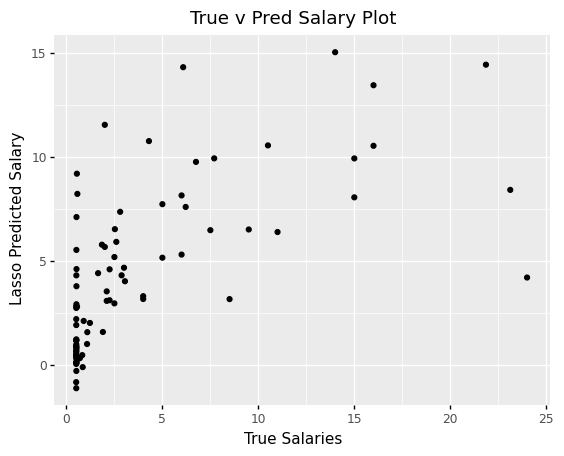

```python
true_v_pred = pd.DataFrame({"lasso_preds": pred_lso_test,
                           "True": y_test,
                           'Error': pred_lso_test - y_test})

true_v_pred

(ggplot(true_v_pred, aes(x = "True", y = "lasso_preds")) + geom_point() +
ggtitle("True v Pred Salary Plot") + labs(x = "True Salaries", y = "Lasso Predicted Salary"))
```

Based on the results from the Lasso model, it is not very accurate in predicting salaries. This can be shown by the low R2 score of 0.40 (40%) and the high mean squared error and mean average error values. This model is also slightly overfit shown by the R2 being higher in the training model (0.436) than the testing model (0.40), so the training model did slightly better than the testing model. When a model is overfit, the model is fit very well to training data and performs well on this data, but when the model is applied to the unseen testing data it performs poorly because it's too well fit to the training data. This shows that the model is too complex, this can be solved through reducing variables. The mean absolute error in the testing model is 2.63 which means that on average the model's predictions were 2.63 million dollars off. The R2 score of 0.40 means that 40% of the variance in our predicted salaries can be explained by our predictor variables, essentially our model is onlt 40% accurate, we obviously want this number to be higher if we want the most accurate predictions.

Although the scores and error metrics are not very good for our lasso model, the true versus predicted plot is not too bad. The plot has a loose linear relationship shown by the upward trend, but the graph somewhat explains why our model has such high error. The model is mostly accurate in predicting salaries in the 0-5 million range shown by the points in this area being clumped together, but once the graph moves into larger salaries it's not as accurate and the model mostly underestimates people with high salaries. This could either be that the model is predicting that these high salary players are being overpaid based on their stats, or the model just isn't accurate and cannot predict high salary players.

## What are the top 5 most significant variables in determining salaries?

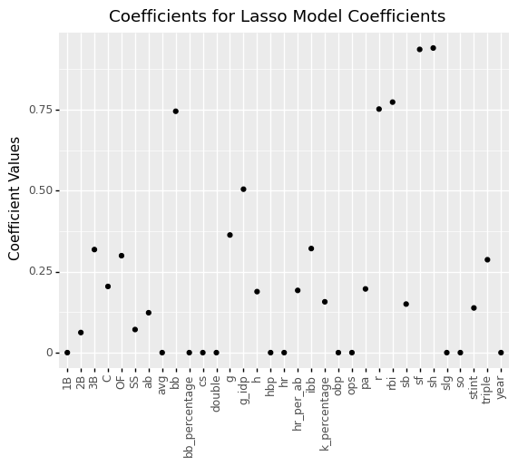

```python
(ggplot(lasso_coef_df, aes(x = "Names", y = "abs(Coefs)")) + geom_point() +
ggtitle("Coefficients for Lasso Model Coefficients") + labs(x = "", y = "Coefficient Values") +
theme(axis_text_x = element_text(angle = 90)))
```

The graph above shows the values of all coefficients for the lasso model. The lasso model finds variables that increase error on the model and turn their coefficients to zero. The coefficients values tell us which variables will have the biggest impact on our predicted salary based on the size of the coefficient. The 5 variables with the highest coefficient values are SF (sac flies, 0.94), SH (sac hits, -0.93), RBI (0.77), BB (walks, 0.74), & R (runs, 0.75). This came as a surprise as we did not expect sacrifice flies or sacrifice hits to have a high significance in determining salary, or even be kept by the lasso model. These 2 variables actually had the 2 highest coefficient values at 0.94 and -0.93. So the model is saying for every sac fly a player hits, their salary will increase by 0.93 million (930K), that simply makes no sence because sacrifice flies are not a statistic that people even look at when determining a player's value. Even weirder, some variables like HR, batting average, and doubles, which we hypothesized would have a large effect on salary, were zeroed out by the lasso model as it believes they increase the error of the model.

# Correlation Matrix and Linear Model

```python
pd.set_option("display.max_rows", None, "display.max_columns", 10)
salaries_clean.corr()

#takes out non-numerical variables
```

|  | year | g | stint | 1B | 2B | ... | hr_per_ab | k_percentage | bb_percentage | salaryM | salary |
| --- | --- | --- | --- | --- | --- | --- | --- | --- | --- | --- | --- |
| year | NaN | NaN | NaN | NaN | NaN | ... | NaN | NaN | NaN | NaN | NaN |
| g | NaN | 1.000000 | -0.013429 | 0.055949 | 0.020602 | ... | 0.268795 | -0.326156 | 0.259734 | 0.457180 | 0.457180 |
| stint | NaN | -0.013429 | 1.000000 | -0.043825 | -0.004610 | ... | -0.040623 | 0.029092 | -0.010477 | -0.075349 | -0.075349 |
| 1B | NaN | 0.055949 | -0.043825 | 1.000000 | -0.134191 | ... | 0.265863 | -0.017186 | 0.229013 | 0.196359 | 0.196359 |
| 2B | NaN | 0.020602 | -0.004610 | -0.134191 | 1.000000 | ... | -0.174402 | -0.132118 | -0.100750 | -0.053324 | -0.053324 |
| 3B | NaN | 0.071077 | 0.065825 | -0.137519 | -0.126692 | ... | 0.045274 | -0.014323 | -0.039137 | -0.038553 | -0.038553 |
| C | NaN | -0.234313 | -0.024533 | -0.167414 | -0.154234 | ... | -0.003548 | 0.085828 | -0.079925 | -0.152617 | -0.152617 |
| OF | NaN | 0.066899 | 0.050680 | -0.290445 | -0.267579 | ... | 0.002513 | 0.112371 | 0.044849 | 0.045740 | 0.045740 |
| SS | NaN | 0.030627 | -0.059163 | -0.137519 | -0.126692 | ... | -0.161594 | -0.105542 | -0.080382 | -0.006767 | -0.006767 |
| ab | NaN | 0.956872 | -0.054337 | 0.066114 | 0.019683 | ... | 0.287154 | -0.347224 | 0.214432 | 0.529893 | 0.529893 |
| pa | NaN | 0.957448 | -0.057351 | 0.083393 | 0.012593 | ... | 0.307141 | -0.339013 | 0.268122 | 0.543531 | 0.543531 |
| avg | NaN | 0.378260 | -0.142085 | 0.038945 | -0.012978 | ... | 0.138084 | -0.518768 | -0.010818 | 0.251903 | 0.251903 |
| slg | NaN | 0.405305 | -0.115877 | 0.184536 | -0.116905 | ... | 0.703222 | -0.208339 | 0.155758 | 0.306999 | 0.306999 |
| obp | NaN | 0.443098 | -0.131589 | 0.137525 | -0.054623 | ... | 0.262657 | -0.422252 | 0.502978 | 0.332121 | 0.332121 |
| ops | NaN | 0.448029 | -0.129990 | 0.179147 | -0.100919 | ... | 0.581565 | -0.305532 | 0.300871 | 0.338005 | 0.338005 |
| r | NaN | 0.882718 | -0.094911 | 0.075394 | 0.006424 | ... | 0.366154 | -0.314518 | 0.284155 | 0.531932 | 0.531932 |
| h | NaN | 0.921101 | -0.089609 | 0.062054 | 0.015794 | ... | 0.269836 | -0.405770 | 0.180590 | 0.533859 | 0.533859 |
| double | NaN | 0.844355 | -0.077962 | 0.106512 | 0.002225 | ... | 0.294524 | -0.351575 | 0.226372 | 0.516369 | 0.516369 |
| triple | NaN | 0.455041 | -0.004583 | -0.166928 | 0.027153 | ... | -0.066530 | -0.193606 | -0.036136 | 0.093638 | 0.093638 |
| hr | NaN | 0.636880 | -0.101154 | 0.262869 | -0.115737 | ... | 0.785177 | -0.026047 | 0.320337 | 0.472628 | 0.472628 |
| rbi | NaN | 0.833320 | -0.093848 | 0.206927 | -0.046147 | ... | 0.550148 | -0.235258 | 0.282958 | 0.582468 | 0.582468 |
| sb | NaN | 0.419590 | -0.004763 | -0.169904 | 0.064322 | ... | -0.125230 | -0.220417 | -0.019467 | 0.125390 | 0.125390 |
| cs | NaN | 0.439850 | -0.024626 | -0.148498 | 0.072904 | ... | -0.114491 | -0.184184 | 0.025319 | 0.105979 | 0.105979 |
| bb | NaN | 0.764379 | -0.058152 | 0.199471 | -0.060179 | ... | 0.389581 | -0.201317 | 0.658421 | 0.533755 | 0.533755 |
| so | NaN | 0.797058 | -0.036116 | 0.101977 | -0.084641 | ... | 0.450732 | 0.141089 | 0.311562 | 0.400473 | 0.400473 |
| ibb | NaN | 0.442002 | -0.089752 | 0.291785 | -0.010788 | ... | 0.350178 | -0.186856 | 0.324752 | 0.448375 | 0.448375 |
| hbp | NaN | 0.504399 | -0.071917 | -0.026078 | 0.018689 | ... | 0.290168 | -0.056876 | 0.138728 | 0.277179 | 0.277179 |
| sh | NaN | 0.178424 | 0.000579 | -0.222635 | 0.105040 | ... | -0.291214 | -0.177455 | -0.139628 | -0.189893 | -0.189893 |
| sf | NaN | 0.648856 | -0.015469 | 0.143885 | 0.008599 | ... | 0.264139 | -0.239571 | 0.172369 | 0.492613 | 0.492613 |
| g_idp | NaN | 0.678357 | -0.036298 | 0.132670 | 0.035451 | ... | 0.204607 | -0.354865 | 0.104194 | 0.481895 | 0.481895 |
| hr_per_ab | NaN | 0.268795 | -0.040623 | 0.265863 | -0.174402 | ... | 1.000000 | 0.185701 | 0.265810 | 0.249717 | 0.249717 |
| k_percentage | NaN | -0.326156 | 0.029092 | -0.017186 | -0.132118 | ... | 0.185701 | 1.000000 | -0.030675 | -0.222572 | -0.222572 |
| bb_percentage | NaN | 0.259734 | -0.010477 | 0.229013 | -0.100750 | ... | 0.265810 | -0.030675 | 1.000000 | 0.259058 | 0.259058 |
| salaryM | NaN | 0.457180 | -0.075349 | 0.196359 | -0.053324 | ... | 0.249717 | -0.222572 | 0.259058 | 1.000000 | 1.000000 |
| salary | NaN | 0.457180 | -0.075349 | 0.196359 | -0.053324 | ... | 0.249717 | -0.222572 | 0.259058 | 1.000000 | 1.000000 |

35 rows × 35 columns

Multicollinearity occurs when 2 predictor variables have a strong relationship to eachother, this is an issue because all predictor variables must be independent and if they are not, the model will be more complex than it needs to be and increase error due to there being 2 variables that can prove the same thing. When inspecting if any of the variables have multicollinearity issues, we found some variable pairs that have high correlation, for example: PA vs AB (0.9972), PA vs H (0.9736), AB vs H (0.9779), Slg vs Ops (0.9642), & R vs H (0.9935). These high correlations occured for two reasons. In the case of PA v H and AB v H, a high value in one of these variables will create a high value for the other, for example if you have a lot of at bats you are more likely to have more hits. For the case of plate appearances vs at bats and SLG v OPS, these variables are highly correlated because they are created variables based off of variables in the original dataset, so when we run a correlation matrix, the original and new variables may have very high correlation due to the fact the new variable is calculated from the original stat. OPS is calculated by adding slugging percentage and on base percentage, so OPS contains SLG so the two variables will have a high correlation.

## Linear Model Based on Correlation Matrix

```python
features2 = ['g', 'pa', 'avg', 'slg', 'obp', 'ops', 'h', 'double',
            'hr', 'rbi', 'sb', 'bb', 'so',
        '1B', '2B', '3B', 'C', 'OF', 'SS']

X2 = salaries_clean[features2]
y2 = salaries_clean["salaryM"]

X2_train, X2_test, y2_train, y2_test = train_test_split(X2,y2, test_size = 0.2)

z2 = StandardScaler()

X2_train[features2] = z2.fit_transform(X2_train[features2])
X2_test[features2] = z2.transform(X2_test[features2])

linear_mod = LinearRegression()
linear_mod.fit(X2_train,y2_train)
linear_coef = linear_mod.coef_

coef_df = pd.DataFrame({"Names": features2, "coefs": linear_coef})

coef_df
```

|  | Names | coefs |
| --- | --- | --- |
| 0 | g | -4.863716 |
| 1 | pa | 9.248715 |
| 2 | avg | 0.253790 |
| 3 | slg | -0.425773 |
| 4 | obp | 0.487029 |
| 5 | ops | -0.095178 |
| 6 | h | -3.334295 |
| 7 | double | 0.121028 |
| 8 | hr | -0.777001 |
| 9 | rbi | 3.621569 |
| 10 | sb | -0.331610 |
| 11 | bb | 0.084305 |
| 12 | so | -1.214724 |
| 13 | 1B | 0.452829 |
| 14 | 2B | -0.063236 |
| 15 | 3B | -0.342689 |
| 16 | C | -0.305113 |
| 17 | OF | 0.706321 |
| 18 | SS | 0.109982 |

```python
pred_lr_train = linear_mod.predict(X2_train)
pred_lr_test = linear_mod.predict(X2_test)

mse_lr_train = mean_squared_error(y2_train, pred_lr_train)
mae_lr_train = mean_absolute_error(y2_train, pred_lr_train)
r2_lr_train = r2_score(y2_train, pred_lr_train)
mse_lr_test = mean_squared_error(y2_test, pred_lr_test)
mae_lr_test = mean_absolute_error(y2_test, pred_lr_test)
r2_lr_test = r2_score(y_test, pred_lr_test)


print("Training:")
print("MSE:", mse_lr_train)
print("MAE:", mae_lr_train)
print("R2:", r2_lr_train)
print(" ")
print("Testing")
print("MSE:", mse_lr_test)
print("MAE:", mae_lr_test)
print("R2:", r2_lr_test)
```

```
Training:
MSE: 19.865463721023538
MAE: 3.191920810528423
R2: 0.43923443029968956

Testing
MSE: 15.502756165041452
MAE: 2.8834417700929116
R2: -0.24169190611176927
```

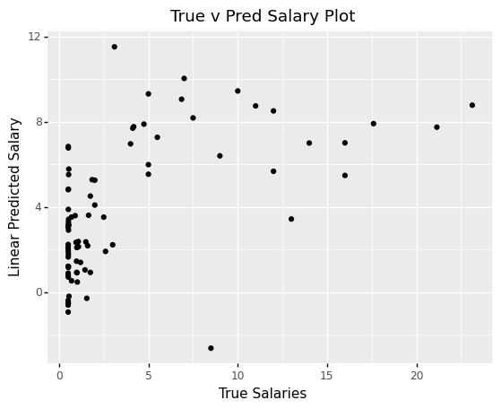

```python
true_v_pred_linear = pd.DataFrame({"linear_preds": pred_lr_test,
                           "True": y2_test,
                           'Error': pred_lr_test - y2_test})

true_v_pred

(ggplot(true_v_pred_linear, aes(x = "True", y = "linear_preds")) + geom_point() +
ggtitle("True v Pred Salary Plot") + labs(x = "True Salaries", y = "Linear Predicted Salary"))
```

[figure not shown]

```python
(ggplot(coef_df2, aes(x = "Names",
                y = "coefs")) +
  geom_point() + ggtitle("Coefficients from Linear Model") + theme_minimal() + theme(axis_text_x = element_text(angle = 90)) +
labs(x = "", y = "Coefficients"))
```

# Do batters with higher salaries actually play that much better than batters with lower salaries?

Expectation Maximization with Gaussian Mixtures clustering algorithms were used to create clusters of players based on their stats and their actual salary. I used batting average, home runs, runs batted in (rbi), and 3 of the variables with the highest coefficient values from our lasso model which are runs, walks (bb), and sacrifice flies (sf).

```python
features3 = ["bb", "sf", "r", "avg", "hr", "rbi", "sh", "salaryM"]

X3 = salaries_clean[features3]

z = StandardScaler()
X[features3] = z.fit_transform(X3)

EM = GaussianMixture(n_components = 2)

EM.fit(X3)

cluster = EM.predict(X3)

print("SILHOUETTE:", silhouette_score(X3,cluster))

X3["cluster"] = cluster
```

```
SILHOUETTE: 0.4004614869300107
```

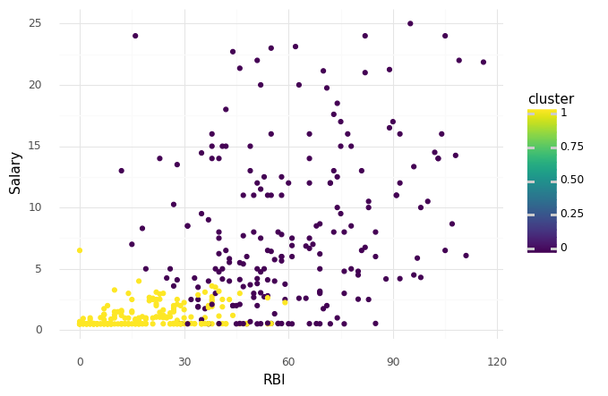

```python
(ggplot(salaries_clean, aes(x = "rbi", y = "salaryM", color = "cluster")) + geom_point() + theme_minimal() +
labs(x = "RBI", y = "Salary"))
```

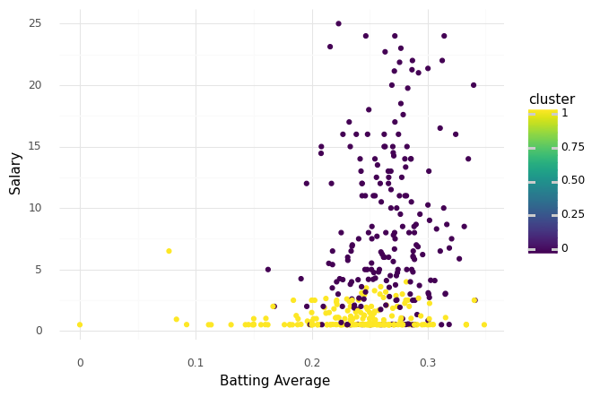

```python
(ggplot(salaries_clean, aes(x = "avg", y = "salaryM", color = "cluster")) + geom_point() + theme_minimal() +
labs(x = "Batting Average", y = "Salary"))
```

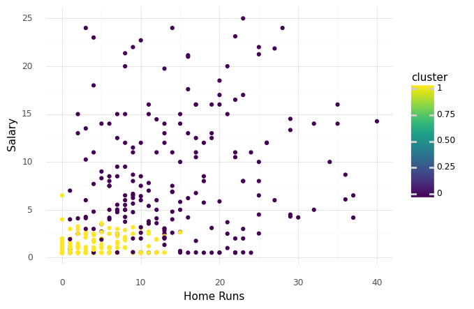

```python
(ggplot(salaries_clean, aes(x = "hr", y = "salaryM", color = "cluster")) + geom_point() + theme_minimal() +
labs(x = "Home Runs", y = "Salary"))
```

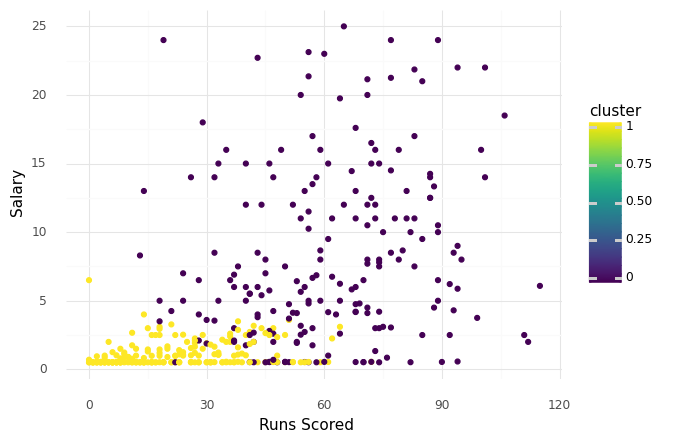

```python
(ggplot(salaries_clean, aes(x = "r", y = "salaryM", color = "cluster")) + geom_point() + theme_minimal() +
labs(x = "Runs Scored", y = "Salary"))
```

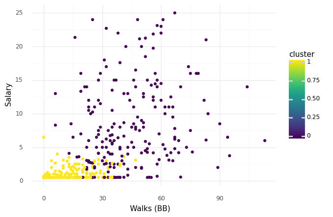

```python
(ggplot(salaries_clean, aes(x = "bb", y = "salaryM", color = "cluster")) + geom_point() + theme_minimal() +
labs(x = "Walks (BB)", y = "Salary"))
```

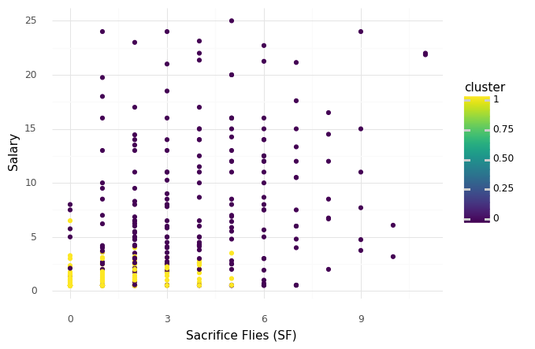

```python
(ggplot(salaries_clean, aes(x = "sf", y = "salaryM", color = "cluster")) + geom_point() + theme_minimal() +
labs(x = "Sacrifice Flies (SF)", y = "Salary"))
```

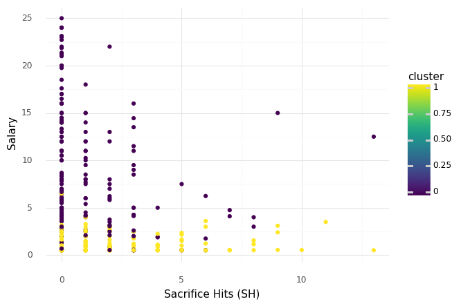

```python
(ggplot(salaries_clean, aes(x = "sh", y = "salaryM", color = "cluster")) + geom_point() + theme_minimal() +
labs(x = "Sacrifice Hits (SH)", y = "Salary"))
```

Overall, players with higher salaries do not clearly play better than those with low salaries because there are many outside factors that can impact salary. This shows that there are many highly performing players who are underpaid and players who are overpaid. For example, younger players don’t make as much and might have a breakout season which could lead to a big payday in the future, while there are older players who have had their payday and make a lot of money but do not play up to their salary because they are old or simply aren’t good and were overpaid. Other outside factors could include how good of an agent a player has, if the player is a popular name, or if a player signs with a rich team (the Yankees) who are willing to overpay to obtain this player.

# Are there any players who are overpaid? How about underpaid? How can we tell?

I answered this question by looking at the difference between the actual and predicted values for salary based on the lasso regression model because it performed better than the linear model. I looked at 2 players who were the most underpaid according to the model, one player who's salary was properly predicted by the model, and 2 players who were the most overpaid according to the model.

```python
true_v_pred = pd.DataFrame({"lasso_preds": pred_lso_test,
                           "True": y_test,
                           'Error': pred_lso_test - y_test})

true_v_pred.sort_values(by = 'Error', ascending = False)
```

|  | lasso_preds | True | Error |
| --- | --- | --- | --- |
| 343 | 11.561689 | 2.000000 | 9.561689 |
| 138 | 9.211749 | 0.545000 | 8.666749 |
| 96 | 14.331694 | 6.083000 | 8.248694 |
| 391 | 8.241021 | 0.570000 | 7.671021 |
| 159 | 7.125913 | 0.525000 | 6.600913 |
| 66 | 10.779764 | 4.300000 | 6.479764 |
| 367 | 5.546983 | 0.519800 | 5.027183 |
| 225 | 7.378712 | 2.800000 | 4.578712 |
| 81 | 4.624309 | 0.525000 | 4.099309 |
| 325 | 6.544838 | 2.525000 | 4.019838 |
| 155 | 5.798422 | 1.850000 | 3.948422 |
| 88 | 4.323175 | 0.517500 | 3.805675 |
| 313 | 5.689362 | 2.000000 | 3.689362 |
| 404 | 5.933655 | 2.600000 | 3.333655 |
| 277 | 3.800437 | 0.522500 | 3.277937 |
| 65 | 9.778687 | 6.750000 | 3.028687 |
| 282 | 4.428425 | 1.650000 | 2.778425 |
| 111 | 7.746350 | 5.000000 | 2.746350 |
| 268 | 5.204309 | 2.500000 | 2.704309 |
| 149 | 2.933388 | 0.520000 | 2.413388 |
| 371 | 4.612811 | 2.250000 | 2.362811 |
| 333 | 2.834203 | 0.512972 | 2.321231 |
| 216 | 2.817492 | 0.553900 | 2.263592 |
| 3 | 9.948685 | 7.700000 | 2.248685 |
| 98 | 2.757495 | 0.512500 | 2.244995 |
| 347 | 8.166822 | 6.000000 | 2.166822 |
| 204 | 2.218698 | 0.512000 | 1.706698 |
| 372 | 4.690363 | 3.000000 | 1.690363 |
| 322 | 3.553837 | 2.100000 | 1.453837 |
| 280 | 4.325945 | 2.875000 | 1.450945 |

[output cut: 52 more lines]

```python
pd.set_option("display.max_rows", 15, "display.max_columns", 19)
salaries_clean.iloc[[44]] #9.85
salaries_clean.iloc[[52]] #8.43
```

|  | name | player_id | pos | year | g | stint | team_id | 1B | 2B | ... | hbp | sh | sf | g_idp | hr_per_ab | k_percentage | bb_percentage | salaryM | salary |
| --- | --- | --- | --- | --- | --- | --- | --- | --- | --- | --- | --- | --- | --- | --- | --- | --- | --- | --- | --- |
| 52 | Mark Teixeira | teixema01 | 1B | 2014 | 123 | 1.0 | NYA | 1 | 0 | ... | 6.0 | 0.0 | 4.0 | 13.0 | 0.05 | 0.213307 | 0.113503 | 23.125 | 23125000 |

1 rows × 39 columns

```python
salaries_clean.iloc[[298]] #6.58
```

|  | name | player_id | pos | year | g | stint | team_id | 1B | 2B | ... | hbp | sh | sf | g_idp | hr_per_ab | k_percentage | bb_percentage | salaryM | salary |
| --- | --- | --- | --- | --- | --- | --- | --- | --- | --- | --- | --- | --- | --- | --- | --- | --- | --- | --- | --- |
| 298 | Hanley Ramirez | ramirha01 | SS | 2014 | 128 | 1.0 | LAN | 0 | 0 | ... | 6.0 | 0.0 | 1.0 | 10.0 | 0.028953 | 0.163424 | 0.108949 | 19.75 | 19750000 |

1 rows × 39 columns

```python
salaries_clean.iloc[[44]] #9.85
```

|  | name | player_id | pos | year | g | stint | team_id | 1B | 2B | ... | hbp | sh | sf | g_idp | hr_per_ab | k_percentage | bb_percentage | salaryM | salary |
| --- | --- | --- | --- | --- | --- | --- | --- | --- | --- | --- | --- | --- | --- | --- | --- | --- | --- | --- | --- |
| 44 | Matt Adams | adamsma01 | 1B | 2014 | 142 | 1.0 | SLN | 1 | 0 | ... | 3.0 | 0.0 | 7.0 | 9.0 | 0.028463 | 0.200704 | 0.045775 | 0.534 | 534000 |

1 rows × 39 columns

```python
salaries_clean.iloc[[338]] #9.44
```

|  | name | player_id | pos | year | g | stint | team_id | 1B | 2B | ... | hbp | sh | sf | g_idp | hr_per_ab | k_percentage | bb_percentage | salaryM | salary |
| --- | --- | --- | --- | --- | --- | --- | --- | --- | --- | --- | --- | --- | --- | --- | --- | --- | --- | --- | --- |
| 338 | Jordy Mercer | mercejo03 | SS | 2014 | 149 | 1.0 | PIT | 0 | 0 | ... | 4.0 | 5.0 | 5.0 | 14.0 | 0.023715 | 0.156966 | 0.061728 | 0.538 | 538000 |

1 rows × 39 columns

```python
salaries_clean.iloc[[50]] #2.5
```

|  | name | player_id | pos | year | g | stint | team_id | 1B | 2B | ... | hbp | sh | sf | g_idp | hr_per_ab | k_percentage | bb_percentage | salaryM | salary |
| --- | --- | --- | --- | --- | --- | --- | --- | --- | --- | --- | --- | --- | --- | --- | --- | --- | --- | --- | --- |
| 50 | Corey Hart | hartco01 | OF | 2014 | 68 | 1.0 | SEA | 0 | 0 | ... | 6.0 | 0.0 | 1.0 | 1.0 | 0.025862 | 0.230469 | 0.0625 | 2.5 | 2500000 |

1 rows × 39 columns

# How well does the model do with predicting the salary for unseen data?

The lasso model is quite bad at predicting salary from unseen data, so I wanted to see how the model would perform on players from more recent years and not 2014, so I chose Mike Trout's stats from 2019 and Brandon Crawford and Juan Soto's stats from 2021. The first step in this plan was to create a dataframe with all the stats from these 3 players, second I zscored our data to put it all on the same scale, and third we applied our lasso model.

```python
player_df = pd.DataFrame({"year": [2019,2021,2021], "Player": ["Mike Trout", "Brandon Crawford", "Juan Soto"],
                         "g": [134,138,151], "stint": [1,1,1], "1B": [0,0,0], "2B": [0,0,0], "3B": [0,0,0], "C": [0,0,0],
                         "SS": [0,1,0], "OF": [1,0,1], "ab": [470, 483, 502], "pa":[600, 549, 654], "avg": [.291,.298,.313],
                         "obp": [.438,.373,.465], "slg": [.645,.522,.534], "ops":[1.083,.895,.999], "r": [110,79, 111],
                         "h": [137,144,157], "double": [27,30,20], "triple":[2,3,2], "hr": [45,24,29], "rbi":[104,90,95],
                         "sb":[11,11,9], "cs":[0,3,7], "bb":[110,56,145], "so":[120,105,93], "ibb":[14,6,23], "hbp":[16,5,2],
                         "sh":[0,0,0], "sf":[4,5,5], "g_idp":[5,8,23], "hr_per_ab":[0.1,0.05,0.06], "k_percentage":[0.26,0.22,0.19],
                         "bb_percentage":[0.18,0.1,0.22], "salary":[37.12,15,8.5]})
player_df
```

|  | year | Player | g | stint | 1B | ... | g_idp | hr_per_ab | k_percentage | bb_percentage | salary |
| --- | --- | --- | --- | --- | --- | --- | --- | --- | --- | --- | --- |
| 0 | 2019 | Mike Trout | 134 | 1 | 0 | ... | 5 | 0.10 | 0.26 | 0.18 | 37.12 |
| 1 | 2021 | Brandon Crawford | 138 | 1 | 0 | ... | 8 | 0.05 | 0.22 | 0.10 | 15.00 |
| 2 | 2021 | Juan Soto | 151 | 1 | 0 | ... | 23 | 0.06 | 0.19 | 0.22 | 8.50 |

3 rows × 35 columns

```python
features4 = ['year','g', 'stint', '1B', '2B', '3B', 'C', 'OF', 'SS', 'ab', 'pa',
       'avg', 'slg', 'obp', 'ops', 'r', 'h', 'double', 'triple', 'hr', 'rbi',
       'sb', 'cs', 'bb', 'so', 'ibb', 'hbp', 'sh', 'sf', 'g_idp', 'hr_per_ab',
       'k_percentage', 'bb_percentage']

X4 = player_df[features4]
y4 = player_df["salary"]

z = StandardScaler()
X4[features4] = z.fit_transform(X4[features4])

preds = lasso_model.predict(X4)
print("Predicted Salaries:", preds)
```

```
Predicted Salaries: [4.78998594 1.47749258 8.48105582]
```

Mike Trout's real salary was 37.12M, but when we ran his stats into our model it showed that he should make 4.79M. The difference between the predicted and actual salaries is 32.3M, so the model did a bad job at predicting salary in this situation.

Juan Soto's real salary was 8.5M while his predicted salary is 8.48M. As you can tell the difference between the real and predicted salaries is very small, meaning this model did well at predicting Soto's salary.

Brandon Crawford's real salary was 15M while his predicted salary is 1.5M. The difference between these two numbers is 13.5M which is a high number. This means that our model did very poorly on predicting this player's salary, as the model says this player should be making 10% of his actual salary.

For context, in 2019 Mike Trout won the MVP and had probably the best season of his already successful career. In 2021 Brandon Crawford and Juan Soto had the best offensive seasons of their careers and finished 3rd and 4th in MVP voting. So these players are all talented players who make a lot of money.

# Conclusion

In conclusion neither of my models were good at predicting salary and I can attribute this because salary is largely subjective. There are many stats a team can use to evaluate if a player is valuable or not and then offer them a salary based off of this value and the team’s situation, but there is no way 100% accurately predict players' salaries based on their stats. A player may make more money simply because of their popularity, if their agent is good, or the wealth of the team they are signing with. This is shown by the fact that the model never predicts someone to have a salary over 15 million, players obtain large contracts because of their skills but also how willing a team is to pay and bargain with you and your agent. This is where salary becomes subjective.

I also think that the model could have been more accurate if there were some more advanced stats included in the model that put all players on the same scale and assign them a value based on all of their stats combined. An example of this is WAR (wins above replacement) and WRC+ (weighted runs created plus). I could not calculate these statistics based on our dataset though. These stats would possibly make the model more accurate because there are players with many different skill sets that have high salaries. There could be power hitters who hit a lot of homeruns and will have high rbi's, slg%, and ops, but might not have the highest batting average; or there could be contact hitters who have high batting averages and obp but have a low number of home runs and rbi's and have low slg% and ops. If we had stats to put all players on the same scale, the model might be better at predicting salaries for these different player skill sets.

Overall, salaries are not something a model can truly predict because of factors that are not connected to the player's stats and skills that may positively or negatively affect their salary.